# Predicting NY Crime

## Data Preparation

Data preparation is essential to guarantee the quality of the model. This section will describe the steps required to clean and prepare data for analysis.

- Features that are irrelevant for this model were removed in the introduction section.
- Column names needs to be modified for coding simplicity

```python
df_i.columns
df_i = df_i.rename(columns = {'DATE OCC': "occ_day",
                              'TIME OCC': "occ_militar_time",
                              'AREA':'area',
                              'Crm Cd':'crm_code',
                              'Vict Age':'vict_age',
                              'Vict Sex':'vict_sex',
                              'Vict Descent':'vict_descent',
                              'Premis Cd':'premis_code',
                              'Weapon Used Cd':'weapon_used_code',
                              'LAT':'lat',
                              'LON':'lon'})
df_i.head()
```

|  | occ_day | occ_militar_time | area | crm_code | vict_age | vict_sex | vict_descent | premis_code | weapon_used_code | lat | lon |
| --- | --- | --- | --- | --- | --- | --- | --- | --- | --- | --- | --- |
| 0 | 01/08/2020 12:00:00 AM | 2230 | 3 | 624 | 36 | F | B | 501.0 | 400.0 | 34.0141 | -118.2978 |
| 1 | 01/01/2020 12:00:00 AM | 330 | 1 | 624 | 25 | M | H | 102.0 | 500.0 | 34.0459 | -118.2545 |
| 2 | 02/13/2020 12:00:00 AM | 1200 | 1 | 845 | 0 | X | X | 726.0 | NaN | 34.0448 | -118.2474 |
| 3 | 01/01/2020 12:00:00 AM | 1730 | 15 | 745 | 76 | F | W | 502.0 | NaN | 34.1685 | -118.4019 |
| 4 | 01/01/2020 12:00:00 AM | 415 | 19 | 740 | 31 | X | X | 409.0 | NaN | 34.2198 | -118.4468 |

- Identify data types and value formats

Python has read some of the value features as integer when they must be categorical string values. This is because, these variables are numerical codes that help to describe values but for python these codes are numerical. For this reason, it is required to change the data type of these features.

```python
# Setting data types of the features

df_i['occ_day']=pd.to_datetime(df_i['occ_day'])
df_i['area']=pd.Categorical(df_i['area'])
df_i['crm_code']=pd.Categorical(df_i['crm_code'])
df_i['vict_descent']=pd.Categorical(df_i['vict_descent'])
df_i['crm_code']=pd.Categorical(df_i['crm_code'])
df_i['premis_code']=pd.Categorical(df_i['premis_code'])
df_i['weapon_used_code']=pd.Categorical(df_i['weapon_used_code'])
print(df_i.dtypes)
print(df_i.shape)
```

```
occ_day             datetime64[ns]
occ_militar_time             int64
area                      category
crm_code                  category
vict_age                     int64
vict_sex                    object
vict_descent              category
premis_code               category
weapon_used_code          category
lat                        float64
lon                        float64
dtype: object
(690454, 11)
```

```python
df_i.head()
```

|  | occ_day | occ_militar_time | area | crm_code | vict_age | vict_sex | vict_descent | premis_code | weapon_used_code | lat | lon |
| --- | --- | --- | --- | --- | --- | --- | --- | --- | --- | --- | --- |
| 0 | 2020-01-08 | 2230 | 3 | 624 | 36 | F | B | 501.0 | 400.0 | 34.0141 | -118.2978 |
| 1 | 2020-01-01 | 330 | 1 | 624 | 25 | M | H | 102.0 | 500.0 | 34.0459 | -118.2545 |
| 2 | 2020-02-13 | 1200 | 1 | 845 | 0 | X | X | 726.0 | NaN | 34.0448 | -118.2474 |
| 3 | 2020-01-01 | 1730 | 15 | 745 | 76 | F | W | 502.0 | NaN | 34.1685 | -118.4019 |
| 4 | 2020-01-01 | 415 | 19 | 740 | 31 | X | X | 409.0 | NaN | 34.2198 | -118.4468 |

- Summary of descriptive statistics

The table below is the first view of all the features. In overall, it describes basic statistics from categorical and numerical variables. For instance, It is possible to observe that the area 1 of LA is the most vulnerable area for crime occurrences and the average age of victims is 30 years old.

```python
df_i.describe(include='all').T
```

|  | count | unique | top | freq | first | last | mean | std | min | 25% | 50% | 75% | max |
| --- | --- | --- | --- | --- | --- | --- | --- | --- | --- | --- | --- | --- | --- |
| occ_day | 690454 | 1182 | 2022-12-02 00:00:00 | 1115 | 2020-01-01 | 2023-03-27 | NaN | NaN | NaN | NaN | NaN | NaN | NaN |
| occ_militar_time | 690454.0 | NaN | NaN | NaN | NaT | NaT | 1333.684692 | 654.383978 | 1.0 | 900.0 | 1412.0 | 1900.0 | 2359.0 |
| area | 690454.0 | 21.0 | 1.0 | 46118.0 | NaT | NaT | NaN | NaN | NaN | NaN | NaN | NaN | NaN |
| crm_code | 690454.0 | 138.0 | 510.0 | 74370.0 | NaT | NaT | NaN | NaN | NaN | NaN | NaN | NaN | NaN |
| vict_age | 690454.0 | NaN | NaN | NaN | NaT | NaT | 29.975965 | 21.683168 | -2.0 | 12.0 | 31.0 | 45.0 | 120.0 |
| vict_sex | 599971 | 4 | M | 286935 | NaT | NaT | NaN | NaN | NaN | NaN | NaN | NaN | NaN |
| vict_descent | 599965 | 19 | H | 212455 | NaT | NaT | NaN | NaN | NaN | NaN | NaN | NaN | NaN |
| premis_code | 690446.0 | 309.0 | 101.0 | 174075.0 | NaT | NaT | NaN | NaN | NaN | NaN | NaN | NaN | NaN |
| weapon_used_code | 239966.0 | 79.0 | 400.0 | 128861.0 | NaT | NaT | NaN | NaN | NaN | NaN | NaN | NaN | NaN |
| lat | 690454.0 | NaN | NaN | NaN | NaT | NaT | 33.961747 | 1.951962 | 0.0 | 34.0132 | 34.0583 | 34.1631 | 34.3343 |
| lon | 690454.0 | NaN | NaN | NaN | NaT | NaT | -117.965521 | 6.769913 | -118.6676 | -118.4294 | -118.3214 | -118.2739 | 0.0 |

- Identification of mission values

```python
df_i.isnull().sum()
df_i.isna().sum()
```

```
occ_day                  0
occ_militar_time         0
area                     0
crm_code                 0
vict_age                 0
vict_sex             90483
vict_descent         90489
premis_code              8
weapon_used_code    450488
lat                      0
lon                      0
dtype: int64
```

`weapon_used_code` missing values required different assumption. There are two points to consider, (1) not all crimes required of a weapon to be committed and (2) a null value could be considered as an $Unknown$ which has the code 500. For this reason, instead of removing these missing values, they were classified as 500 weapon_used_code. Finally, the `victim_sex` feature is filtered to removed values "H" and "X" because these values are not able to describe any profile of the victims. The entry process could had mistakes.

These changes reduced the dataset from 690,454 rows to 516,988 rows

```python
# Removing missing values
df_1 = df_i.dropna(subset=["vict_sex","vict_descent","premis_code"])


# Filling NaN values with category code 500.0 within weapon_used_code
df_1["weapon_used_code"]=df_1["weapon_used_code"].fillna(500.0)

# Victim age > 0
df_1 = df_1[df_1['vict_age'] >0]

# Victim sex re labelling
df_1 = df_1[df_1["vict_sex"]!="H"]
df_1 = df_1[df_1["vict_sex"]!="X"]
df_i['vict_sex']=pd.Categorical(df_i['vict_sex'])

print("The new shape of the dataset after removing missing values",df_1.shape)
df_1.isna().sum()
```

```
The new shape of the dataset after removing missing values (516988, 11)
```

```
occ_day             0
occ_militar_time    0
area                0
crm_code            0
vict_age            0
vict_sex            0
vict_descent        0
premis_code         0
weapon_used_code    0
lat                 0
lon                 0
dtype: int64
```

- Generation of random sample

This step is required because the current size of dataset may slow future analysis and it is not required to have the full data to build the predictive model. The sampling was randomly generated to select 5% of the total of observations (25,850).

```python
# Sampling data
df_sample = df_1.sample(n=25850, random_state=999)
print(df_sample.shape)
df_sample.sample(10, random_state=999)
```

```
(25850, 11)
```

|  | occ_day | occ_militar_time | area | crm_code | vict_age | vict_sex | vict_descent | premis_code | weapon_used_code | lat | lon |
| --- | --- | --- | --- | --- | --- | --- | --- | --- | --- | --- | --- |
| 608173 | 2022-01-15 | 1830 | 13 | 440 | 20 | F | H | 210.0 | 500.0 | 33.9893 | -118.2521 |
| 275379 | 2021-08-13 | 900 | 11 | 626 | 44 | F | H | 501.0 | 400.0 | 34.0934 | -118.2947 |
| 578223 | 2022-06-24 | 1630 | 11 | 850 | 25 | F | H | 108.0 | 500.0 | 34.0959 | -118.2073 |
| 672518 | 2023-02-14 | 1315 | 13 | 354 | 47 | M | H | 101.0 | 500.0 | 33.9902 | -118.2483 |
| 85825 | 2020-04-20 | 900 | 9 | 740 | 25 | M | O | 108.0 | 500.0 | 34.2012 | -118.4312 |
| 469938 | 2022-10-19 | 1432 | 1 | 442 | 24 | M | H | 405.0 | 500.0 | 34.0483 | -118.2631 |
| 580087 | 2022-10-24 | 1800 | 10 | 624 | 53 | F | H | 502.0 | 400.0 | 34.2012 | -118.5261 |
| 43375 | 2020-04-29 | 808 | 3 | 626 | 22 | F | H | 501.0 | 400.0 | 34.0155 | -118.2978 |
| 496746 | 2022-01-27 | 1245 | 10 | 440 | 40 | F | W | 119.0 | 500.0 | 34.1993 | -118.5471 |
| 104910 | 2020-07-17 | 630 | 14 | 310 | 68 | M | W | 502.0 | 500.0 | 33.9720 | -118.4271 |

- Finally, the value format for `occ_day` needed to be change to extract just the weekday value.

This step is applied after the sampling because the process time required to execute this action is significant.

- This is the descriptive statistics of the sample

```python
df_sample.describe(include='all').T
```

|  | count | unique | top | freq | first | last | mean | std | min | 25% | 50% | 75% | max |
| --- | --- | --- | --- | --- | --- | --- | --- | --- | --- | --- | --- | --- | --- |
| occ_day | 25850 | 1182 | 2022-12-02 00:00:00 | 52 | 2020-01-01 | 2023-03-27 | NaN | NaN | NaN | NaN | NaN | NaN | NaN |
| occ_militar_time | 25850.0 | NaN | NaN | NaN | NaT | NaT | 1318.475899 | 655.219179 | 1.0 | 900.0 | 1400.0 | 1845.0 | 2359.0 |
| area | 25850.0 | 21.0 | 1.0 | 1819.0 | NaT | NaT | NaN | NaN | NaN | NaN | NaN | NaN | NaN |
| crm_code | 25850.0 | 107.0 | 624.0 | 2687.0 | NaT | NaT | NaN | NaN | NaN | NaN | NaN | NaN | NaN |
| vict_age | 25850.0 | NaN | NaN | NaN | NaT | NaT | 39.874081 | 15.54012 | 2.0 | 28.0 | 37.0 | 50.0 | 99.0 |
| vict_sex | 25850 | 2 | M | 13190 | NaT | NaT | NaN | NaN | NaN | NaN | NaN | NaN | NaN |
| vict_descent | 25850 | 18 | H | 10441 | NaT | NaT | NaN | NaN | NaN | NaN | NaN | NaN | NaN |
| premis_code | 25850.0 | 237.0 | 501.0 | 5754.0 | NaT | NaT | NaN | NaN | NaN | NaN | NaN | NaN | NaN |
| weapon_used_code | 25850.0 | 64.0 | 500.0 | 15961.0 | NaT | NaT | NaN | NaN | NaN | NaN | NaN | NaN | NaN |
| lat | 25850.0 | NaN | NaN | NaN | NaT | NaT | 33.97117 | 1.884181 | 0.0 | 34.014 | 34.05895 | 34.166375 | 34.3292 |
| lon | 25850.0 | NaN | NaN | NaN | NaT | NaT | -117.994968 | 6.53396 | -118.6676 | -118.4328 | -118.3246 | -118.2749 | 0.0 |

```python
from datetime import datetime


for i in df_sample.index:
    df_sample['occ_day'][i] = datetime.weekday(df_sample['occ_day'][i])
```

The weekday from each value of these feature was extracted by using 'datetime' function from datetime module. Now the values are categorical from 0 to 6, where 0 is equal to Monday and 6 is equal to Sunday.

```python
df_sample.head()
```

|  | occ_day | occ_militar_time | area | crm_code | vict_age | vict_sex | vict_descent | premis_code | weapon_used_code | lat | lon |
| --- | --- | --- | --- | --- | --- | --- | --- | --- | --- | --- | --- |
| 596348 | 1 | 1210 | 4 | 354 | 38 | F | H | 503.0 | 500.0 | 34.0234 | -118.2102 |
| 683889 | 3 | 1600 | 3 | 624 | 17 | F | B | 502.0 | 400.0 | 34.0055 | -118.2937 |
| 221084 | 5 | 1530 | 1 | 740 | 41 | M | H | 122.0 | 500.0 | 34.0459 | -118.2526 |
| 527014 | 0 | 1606 | 1 | 341 | 19 | M | C | 124.0 | 500.0 | 34.0566 | -118.2318 |
| 429174 | 0 | 1207 | 7 | 354 | 35 | F | H | 501.0 | 500.0 | 34.0623 | -118.3462 |

## Data Visualisation

The dataset was pre-procesed and it is ready to be used in analysis and modelling.

### Univariate Analysis

- Bar chart of ranking of areas most vulnerable for crime

In the other hand, the Figure 2 shows how many occurrences have the areas with lowest report of crime. In general, the number of crimes reported are under 1300 reports from 2020.

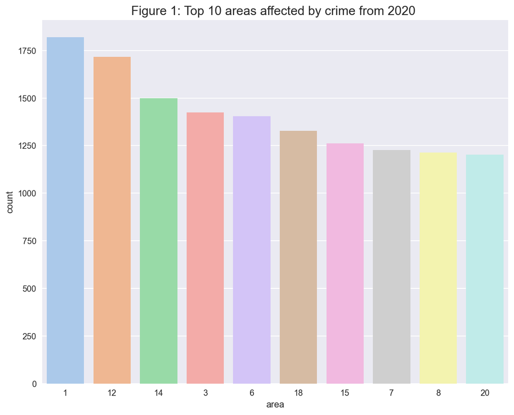

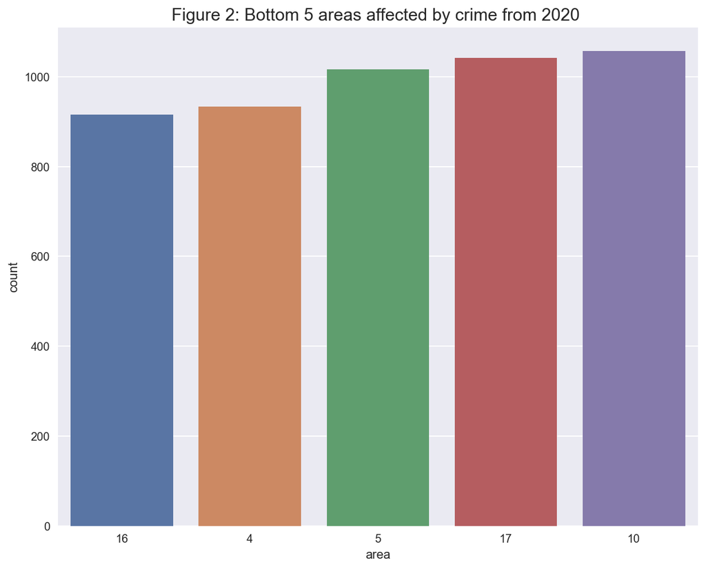

```python
#Top 10
Rank_10 = df_sample['area'].value_counts().nlargest(10).index.tolist()

plt.figure(figsize = (10,8))

fig_1 = sns.countplot(x = 'area', data = df_sample, palette = 'pastel',
                    order = Rank_10)
fig = plt.title('Figure 1: Top 10 areas affected by crime from 2020 ', fontsize = 15)
plt.show()

# bottom 5
Rank_5 = df_sample['area'].value_counts().nsmallest(5).index.tolist()

plt.figure(figsize = (10,8))

fig_2 = sns.countplot(x = 'area', data = df_sample, palette = 'deep',
                    order = Rank_5)
fig = plt.title('Figure 2: Bottom 5 areas affected by crime from 2020 ', fontsize = 15)
plt.show()
```

- Bar chart of number of crimes by sex:

The following graph shows the number of crime occurrence in LA from 2020 by sex definition. In overall, there more male victims of crimes than females, but the difference is not significant.

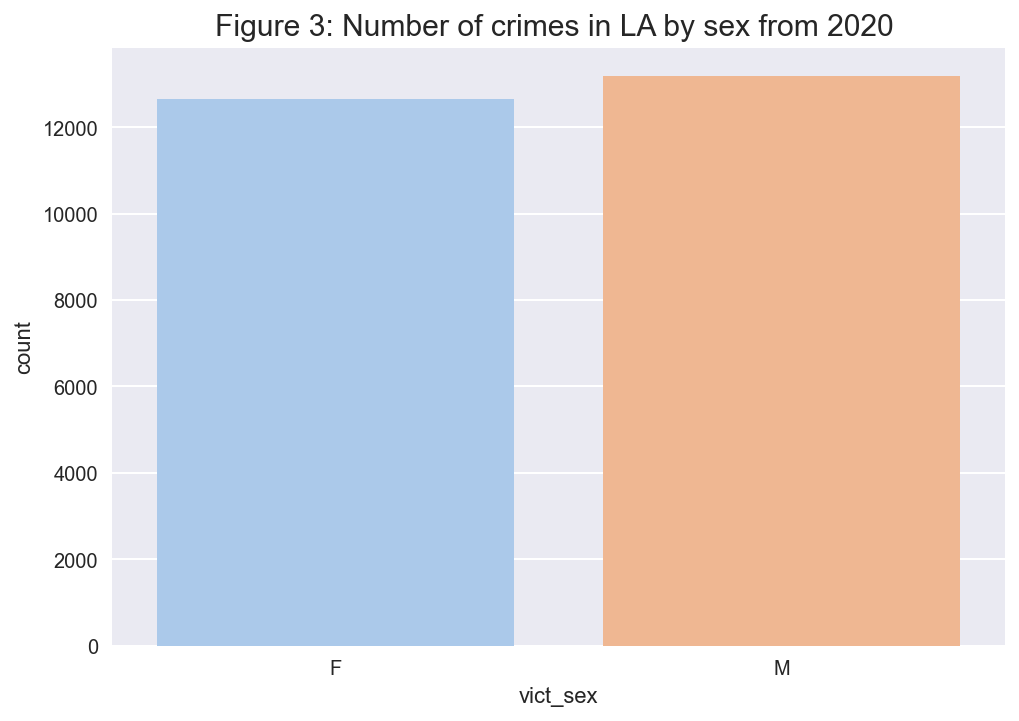

```python
fig_3 = sns.countplot(x = 'vict_sex', data = df_sample, palette = 'pastel')

fig = plt.title('Figure 3: Number of crimes in LA by sex from 2020 ', fontsize = 15)
plt.show()
```

- Box plot and Histogram of victims age:

The boxplot below shows the normally age of the victims of crime in LA from 2020. The minimum age of a victim was 2 and the maximum is 99 years old. The normal range of the victims age is in between 25 to 50 years old. Additionally, the histogram shows a normal distribution skewed to the right of the data.

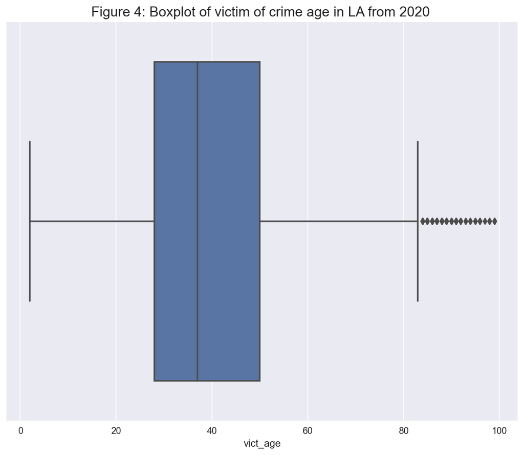

```python
plt.figure(figsize = (10,8))

fig_4 = sns.boxplot(x = 'vict_age', data = df_sample).set_title('Figure 4: Boxplot of victim of crime age in LA from 2020 ',
                                                                fontsize = 15)
plt.show()
```

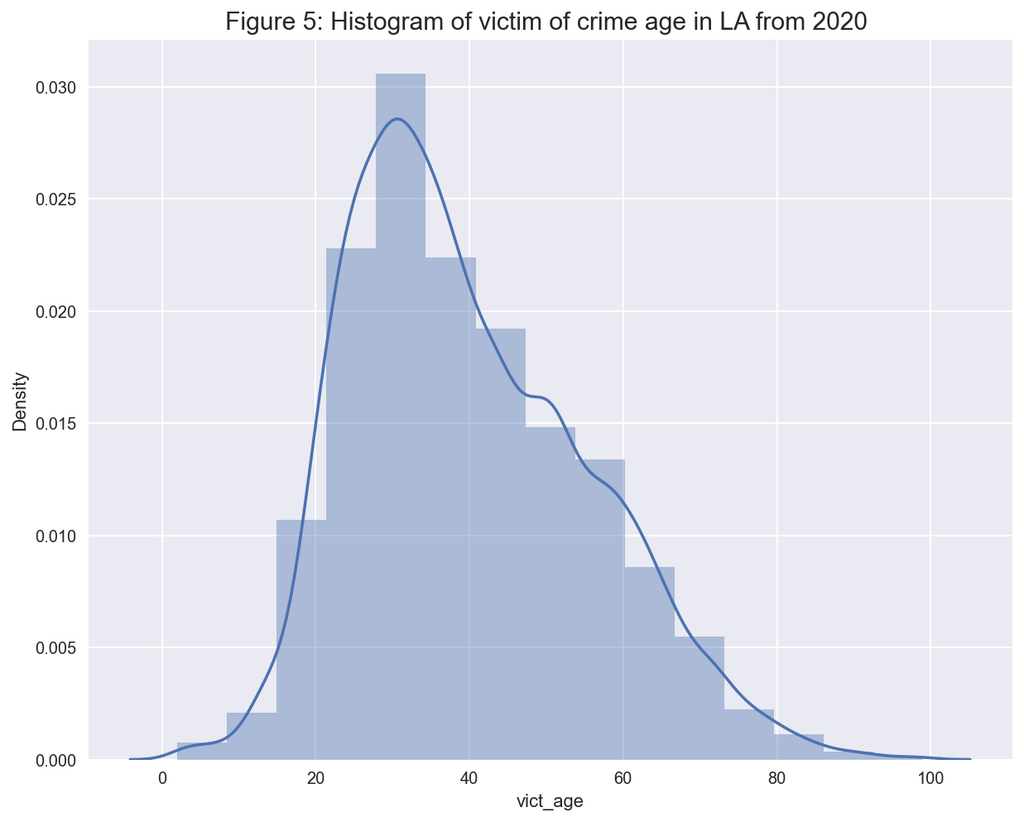

```python
plt.figure(figsize = (10,8))

fig_5 = sns.distplot(df_sample['vict_age'],kde=True,bins=15).set_title('Figure 5: Histogram of victim of crime age in LA from 2020 ',
                                                                fontsize = 15)
plt.show()
```

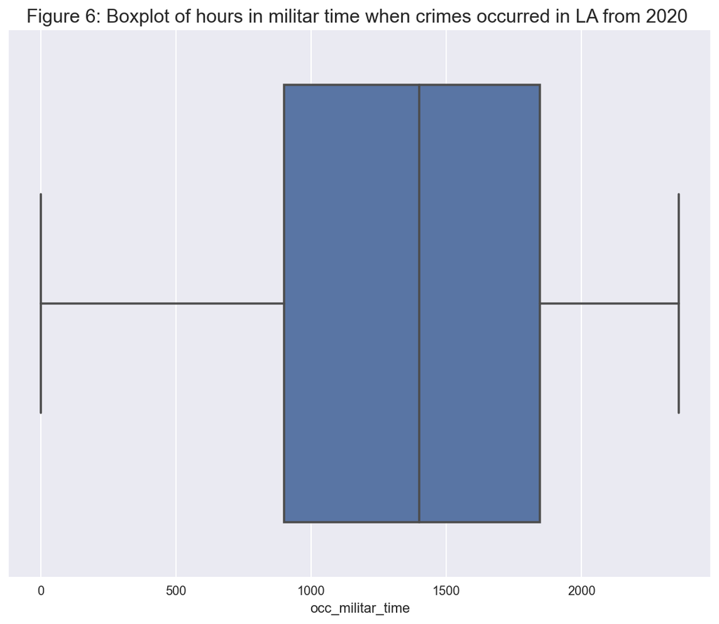

```python
plt.figure(figsize = (10,8))

fig_6 = sns.boxplot(x = 'occ_militar_time', data = df_sample).set_title('Figure 6: Boxplot of hours in militar time when crimes occurred in LA from 2020 ',
                                                                fontsize = 15)
plt.show()
```

[figure not shown]

```python
plt.figure(figsize = (10,8))

fig_7 = sns.distplot(df_sample['occ_militar_time'],kde=True,bins=15).set_title('Figure 7: Boxplot of hours in militar time when crimes occurred in LA from 2020 ',
                                                                fontsize = 15)
plt.show()
```

### Multivariate Analysis

- Boxplot of victim of crime age by day of occurrence:

In overall, the boxplot below shows a possible similarity between the average of victims of crime age across the 7 days of the week. However, It is possible that the age of victims of crime is different than the others days. This assumption must be tested by hypothesis.

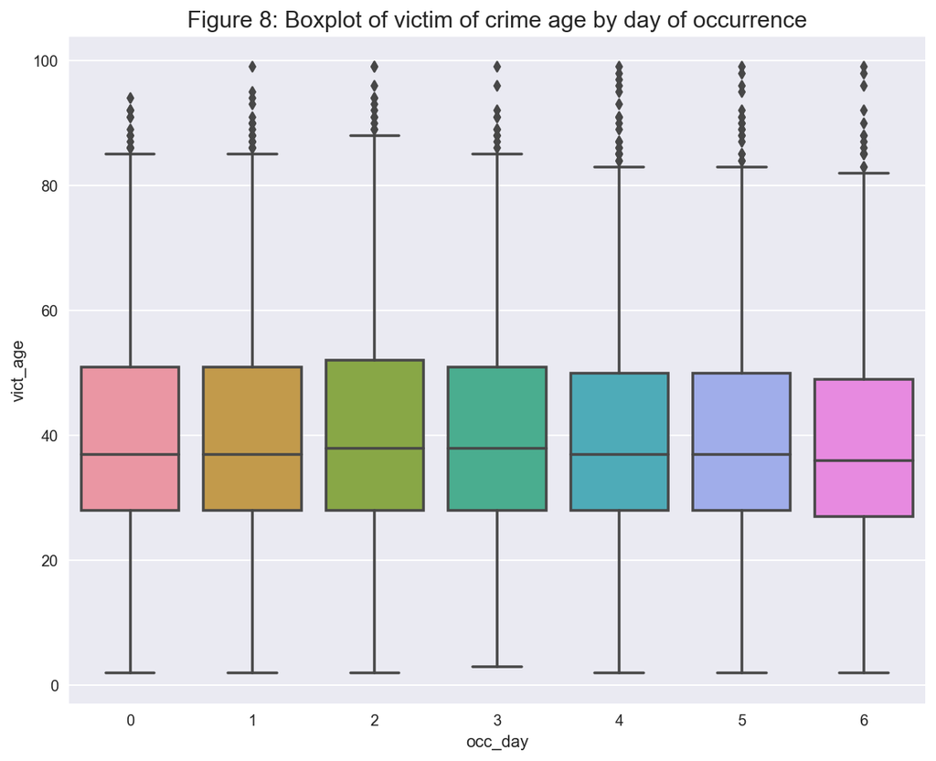

```python
plt.figure(figsize = (10,8))

fig_8 = sns.boxplot(df_sample['occ_day'], df_sample['vict_age']).set_title('Figure 8: Boxplot of victim of crime age by day of occurrence',
                                                                fontsize = 15)

plt.show()
```

- Boxplot of victim of crime age by LA Area:

In general the average age of victims in LA fluctuates from 30 years old to 45 years old. Victims over or equal 40 years old are normally assaulted in the areas 8, 10 and 17. The area number 6 commonly reports crimes of victims under 35 years old.

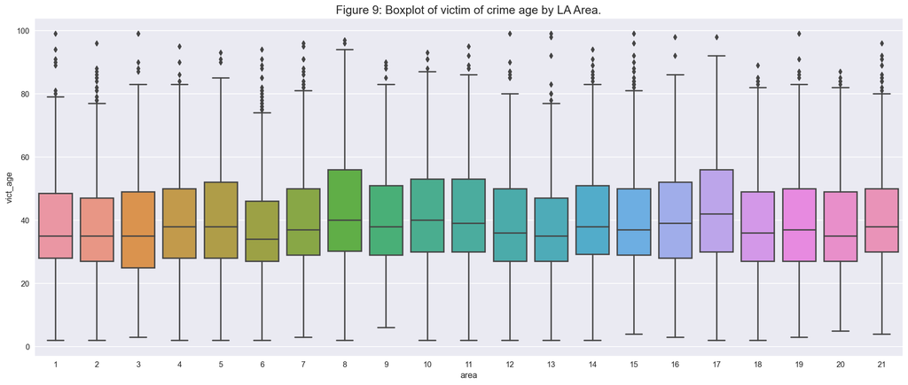

```python
plt.figure(figsize = (20,8))

fig_9 = sns.boxplot(df_sample['area'], df_sample['vict_age']).set_title('Figure 9: Boxplot of victim of crime age by LA Area.',
                                                                fontsize = 15)

plt.show()
```

Overall, each area has recorded over 600 cases in LA from 2020. It seems that number of crimes do not discriminate by sex in the majority of areas. There are exceptions where one sex is more affected than the other by crimes. For instance, the area 1 registered a significant difference in cases by sex, there are more cases of crimes for male than female. In contrast, the area 12 has more female victims than male victims.

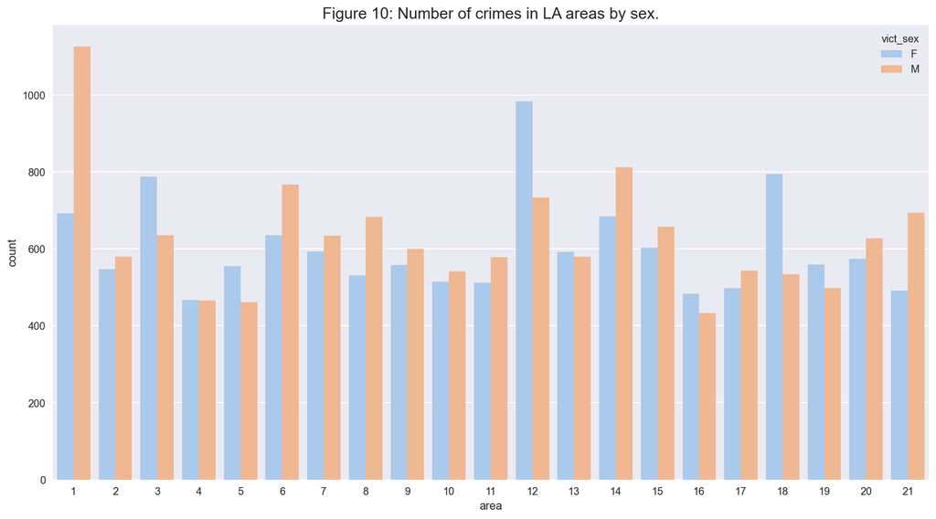

```python
plt.figure(figsize = (15,8))

fig_10 = sns.countplot(data=df_sample, x ="area", hue="vict_sex", palette = "pastel").set_title('Figure 10: Number of crimes in LA areas by sex.',
                                                                fontsize = 15)

plt.show();
```

The following boxplot shows the average age of victims per weekday by sex of the victim. In general, the graphs shows that there is average of age victims can be statistically similar in across the 7 days of the week. Additionally, it is visible that the average of male victims is greater than the average of female victims.

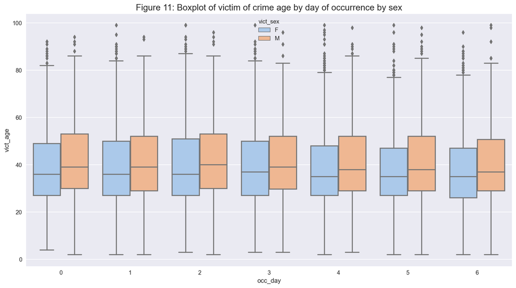

```python
plt.figure(figsize = (15,8))

fig_11 = sns.boxplot(df_sample['occ_day'], df_sample['vict_age'],
                     hue=df_sample["vict_sex"], palette="pastel").set_title('Figure 11: Boxplot of victim of crime age by day of occurrence by sex',
                                                                fontsize = 15)

plt.show()
```

- Boxplot of victim of crime age by area by sex:

The following boxplot illustrates the victim of a crime age in each area of Los Angeles by sex of the victim. In overall, the mean of age fluctuates between 35 and 45, the area with lower range of age of victims is the area 6 and the area 8 has the biggest range of age of victims. Additionally, the mean victim age in males is greater than the female average victim age across 20 LA areas, except for the area 8 where female average age of victims is greater.

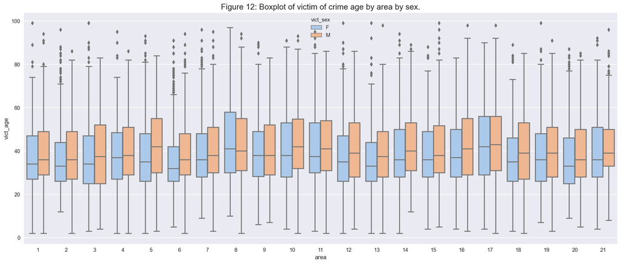

```python
plt.figure(figsize = (20,8))

fig_11 = sns.boxplot(df_sample['area'], df_sample['vict_age'],
                     hue=df_sample["vict_sex"], palette="pastel").set_title('Figure 12: Boxplot of victim of crime age by area by sex.',
                                                                fontsize = 15)
plt.show()
```

## Literature Review

The massive increment in criminal records demands that police departments develop and deploy technology to prevent criminal activities. Data science developments can help to create technological tools for the analysis of criminal records by applying different machine learning paradigms. As evidence, many studies of supervised machine learning techniques have proposed models to predict future instances of crime based on the type of features and the objective variable (Bshayer, et al., 2020). Although there are many possible models, this paper will explain predictive models for crime prevention based on these three ML paradigms information-based, probability-based and similarity-based.

Criminology is a science that studies the demographic and social aspects of a crime. This field extracts information to investigate crimes and predicts future occurrences based on criminal records. For this reason, police and similar security institutions require criminal analysis with statistical outputs to determine crime patterns that may help to anticipate future occurrences. For instance, a police department can identify vulnerable areas for crime and common victim profiles by descriptive analysis of historical data. As result, security institutions require technology applied to criminal analysis to reduce the number of felonies.

Then, machine learning is a useful instrument to be added to criminal analysis because it can assist with forecasting essential information about crime events by applying predictive models. To aim this, the selection of features, objective variables and ML paradigms are crucial steps within the predictive data analysis lifecycle. This is because crime prediction in real-time is a challenging task that may contain multiple dimensions of space (GPS position, area, region), time (date, time) and explanatory factors (social demography of the crime, victim profile) to generate the final set of solutions (M. Wawrzyniak, et al., 2018). Therefore, there are a large number of models for crime detection regarding the ML paradigm.

Firstly, information-based learning can be applied to crime prediction models with categorical or numerical variables. Algorithms based on decision tree theory may offer relevant solutions when the target variable is the space of the occurrences or the amount of occurrences per day. For example, Zhang, Liu, Lan, Song, Xiao & Chen (2022) proposed to predict the number of thefts within an area by analysing the area features (Area containing certain population age, restaurant area, department store, etc.) and applying XGBoost algorithm which is a learning method able to build different types of decision trees and flexible to configurate. Another example of a data-driven crime detection model is proposed by M. Wawrzyniak et al. (2018), who have built an algorithm using Neural Networking to predict the number of crime occurrences per day by interconnecting time series data of criminal records and exogenous variables of different instances.

Secondly, the probabilistic approach can contribute to the classification of future crimes. Naïve Bayes is a probability-based algorithm that can be used in categorical features to classify if the feature is applicable or not for the observation. For instance, Khan, M., Ali, A., & Alharbi, Y. (2022) studied the efficiency of Naïve Bayes model to forecast the probability of violent or nonviolent crimes. Although the study did not show the best results for the Naïve Bayes model, it illustrates the possibility to use probabilistic ML paradigms to classify criminal variables.

Finally, Clustering models are an alternative to classify crime occurrences by applying genetic algorithms within the formula. GA’s are algorithms that improve their accuracy by evolving their fitness function. As evidence, Kiani, R., Mahdavi, S., & Keshavarzi, (2015) applied this idea by improving outlier detection before processing the data and defining a fitness function on the accuracy and classification error parameters. As a result, it is possible to predict the number of occurrences by the classification of crimes.

In conclusion, police departments may have significant benefits from predictive models no matter the paradigm. This is because machine learning can contribute essential information to classify and predict felonies. For this reason, it is vital to select the correct features to make of predicting real-time crime less challenging and more accurate.

## Conclusions

- There areas more affected than others among the 21 divided areas of LA
- In general the average range of victims age is 30 to 40 years old
- There are areas where female population is more affected than male population
- The average female victim age is lower than the average male victim age
- The area 1 of Los Angeles is the most affected by crime of different kind.

In conclusion, the LAPD requires of a technological development that helps to predict which area is more vulnerable to have crime occurrences depending of the type of crime, day and time. For this reason a Machine Learning model able to use the feature variables of time, space and descriptive variables to forecast areas is a neccesity to optimise the distribution of the police force in each of these areas depending of their level of risk.

## References

• Z. M. Wawrzyniak et al., "Data-driven models in machine learning for crime prediction," 2018 26th International Conference on Systems Engineering (ICSEng), Sydney, NSW, Australia, 2018, pp. 1-8, doi: 10.1109/ICSENG.2018.8638230.

• M. Raja Suguna, R. Beaulah Jeyavathana, and K. V. Kanimozhi (2022). Comparative analysis of crime predictions using machine learning algorithms with geospatial features", AIP Conference Proceedings 2393, 020004

• O. Llaha, "Crime Analysis and Prediction using Machine Learning," 2020 43rd International Convention on Information, Communication and Electronic Technology (MIPRO), Opatija, Croatia, 2020, pp. 496-501

• Bshayer S. Aldossari, Futun M. Alqahtani, Noura S. Alshahrani, Manar M. Alhammam, Razan M. Alzamanan, Nida Aslam, and Irfanullah. 2020. A Comparative Study of Decision Tree and Naive Bayes Machine Learning Model for Crime Category Prediction in Chicago. In Proceedings of 2020 the 6th International Conference on Computing and Data Engineering (ICCDE 2020). Association for Computing Machinery, New York, NY, USA, 34–38.

• Xu Zhang, Lin Liu, Minxuan Lan, Guangwen Song, Luzi Xiao, Jianguo Chen (2022). Interpretable machine learning models for crime prediction, Computers, Environment and Urban Systems, Volume 94,2022,101789, ISSN 0198-9715

• Jenga, K., Catal, C. & Kar, G(2023). Machine learning in crime prediction. J Ambient Intell Human Comput 14, 2887–2913 (2023).

• Shah, N., Nandish, B., & Manan, S. (2021). Crime forecasting: a machine learning and computer vision approach to crime prediction and prevention. Visual Computing for Industry Biomedicine, and Art, 4(1)

• S. S. Kshatri, D. Singh, B. Narain, S. Bhatia, M. T. Quasim and G. R. Sinha. (2021), "An Empirical Analysis of Machine Learning Algorithms for Crime Prediction Using Stacked Generalization: An Ensemble Approach," in IEEE Access, vol. 9, pp. 67488-67500, 2021

• Ahishakiye, Emmanuel & Opiyo, Elisha & Wario, Ruth & Niyonzima, Ivan. (2017). A Performance Analysis of Business Intelligence Techniques on Crime Prediction. International Journal of Computer and Information Technology. 06. 84 - 90.

• Kumari, Pratibha & Gahalot, Akanksha & Uprant, & Dhiman, Suraina & Chouhan, Lokesh. (2020). Crime Prediction and Analysis. 1-6. 10.1109/IDEA49133.2020.9170731.

• Kiani, R., Mahdavi, S., & Keshavarzi, A. (2015). Analysis and Prediction of Crimes by Clustering and Classification. International Journal of Advanced Research in Artificial Intelligence, 4(8).

• Khan, M., Ali, A., & Alharbi, Y. (2022). Predicting and Preventing Crime: A Crime Prediction Model Using San Francisco Crime Data by Classification Techniques. Complexity (New York, N.Y.), 2022, 1–13.

• Jangra M, Kalsi S (2019) Crime analysis for multistate network using naïve Bayes classifier. Int J Comput Sci Mob Comput 8(6):134–143